# Lecture 9: Preprocessing and Practice

Nick Huntington-Klein

25 April, 2020

## Preprocessing

- One of the reasons to favor **ggplot2** for graphing is that it uses R
- And R is waaaay better than Excel at *preparing your data to be graphed*
- We can’t do a full data wrangling course, but we can discuss some **dplyr** basics
- **dplyr** is a data manipulation package, loadable with `library(dplyr)`, or get both **ggplot2** and **dplyr** (and other stuff) with `library(tidyverse)`.

## Data Manipulation

- As always, our goal with data communication is to *think about the data points we want to show* (in a table, graph, etc.)
- And then *manipulate the data so it contains those points*
- And then graph
- Or, if our graph does some calculations of its own, manipulate the data so it’s ready to be calculated-upon

## dplyr

- **dplyr** works to help us manipulate our data by operating with a limited set of *verbs* that change our data
- It works seamlessly with a *pipe*, `%>%`, which passes us from one verb to the next
- Giving us a “sentence” of how we want our data to be manipulated, and we end up with our ideal data at the end!
- Don’t forget to assign your manipulated data to an object so you save it! (`<-`)

## dplyr verbs

- **dplyr** and the associated **tidyr** have many, many, many tools, way more than I can cover here
- For a much more thorough introduction, try the **swirl** package and the Getting and Cleaning Data class (`swirl::install_course("Getting and Cleaning Data")`)
- Let’s assume you’ve read in some data with `read.csv` or `load()` or `data()`
- Or read in data using a package function: `read_excel` in **readxl**, `read_` in `haven` or `read.` in **foreign** for Stata, SAS, etc., or `fread` for big CSV files in `data.table`
- And clean our data from there!

## The pipe

- Technically not *from* **dplyr** but it holds the whole thing together
- And in general makes R code much nicer
- `x %>% y(option=1,option=2)` is the same as `y(x,option=1,option=2)`
- The pipe fills in the first argument with whatever’s on the left
- Chain them for bonus points! `x %>% y() %>% z()` = `z(y(x))`
- Doesn’t just work with **dplyr**! `mtcars %>% pull(mpg) %>% mean()` why not?

## filter

- Pick *rows*/observations with `filter`
- Use logical `TRUE/FALSE` expressions inside. Use `==` to check equality or `%in%` to check belonging in a list
- Also see `slice()` to pick by row number instead

```r
# Note I'm not saving this anywhere - after you see the results they will be lost to time
mtcars %>%
  filter(cyl %in% c(4,6), am == 0)
```

```
##                 mpg cyl  disp  hp drat    wt  qsec vs am gear carb
## Hornet 4 Drive 21.4   6 258.0 110 3.08 3.215 19.44  1  0    3    1
## Valiant        18.1   6 225.0 105 2.76 3.460 20.22  1  0    3    1
## Merc 240D      24.4   4 146.7  62 3.69 3.190 20.00  1  0    4    2
## Merc 230       22.8   4 140.8  95 3.92 3.150 22.90  1  0    4    2
## Merc 280       19.2   6 167.6 123 3.92 3.440 18.30  1  0    4    4
## Merc 280C      17.8   6 167.6 123 3.92 3.440 18.90  1  0    4    4
## Toyota Corona  21.5   4 120.1  97 3.70 2.465 20.01  1  0    3    1
```

## select

- Pick *columns*/variables with `select`
- If you have a lot of variables to pick, look into `across` in the documentation

```r
mtcars %>%
  select(mpg, hp, cyl) %>%
  head()
```

```
##                    mpg  hp cyl
## Mazda RX4         21.0 110   6
## Mazda RX4 Wag     21.0 110   6
## Datsun 710        22.8  93   4
## Hornet 4 Drive    21.4 110   6
## Hornet Sportabout 18.7 175   8
## Valiant           18.1 105   6
```

## mutate

- `mutate` adds a new variable (or multiple new variables at once!)

```r
mtcars2 <- mtcars %>%
  mutate(MPG_Horsepower_Ratio = mpg/hp) %>%
  select(mpg,hp,MPG_Horsepower_Ratio)
head(mtcars2)
```

```
##                    mpg  hp MPG_Horsepower_Ratio
## Mazda RX4         21.0 110            0.1909091
## Mazda RX4 Wag     21.0 110            0.1909091
## Datsun 710        22.8  93            0.2451613
## Hornet 4 Drive    21.4 110            0.1945455
## Hornet Sportabout 18.7 175            0.1068571
## Valiant           18.1 105            0.1723810
```

## arrange

- Arrange *sorts* the data
- Handy if you want to print your data as a table (often by passing it to `knitr::kable` or saving it with some `write_` or `write.` function) or use things like lags or `first()`

```r
mtcars %>%
  arrange(cyl, hp) %>%
  select(cyl, hp, mpg) %>%
  slice(1:5) %>%
  knitr::kable()
```

## arrange

```r
mtcars %>%
  arrange(cyl, hp) %>%
  select(cyl, hp, mpg) %>%
  slice(1:5) %>%
  knitr::kable()
```

|  | cyl | hp | mpg |
| --- | --- | --- | --- |
| Honda Civic | 4 | 52 | 30.4 |
| Merc 240D | 4 | 62 | 24.4 |
| Toyota Corolla | 4 | 65 | 33.9 |
| Fiat 128 | 4 | 66 | 32.4 |
| Fiat X1-9 | 4 | 66 | 27.3 |

## group_by

- One of the best things about **dplyr** is `group_by` which lets you perform calculations *by group*
- “Group” can be lots of things - categories, time, actual groups
- Collapse the data to group-level with `summarize()` to get the exact summary statistics you want to graph
- Create new variables with `mutate()` to do things like subtract group means or take values relative to a certain point

## group_by and mutate

```r
data(gapminder, package = 'gapminder')
gapminder <- gapminder %>%
  arrange(country, year) %>%
  group_by(country) %>%
  # "first()" calculated within-country
  mutate(pop_growth_since_1952 = (pop/first(pop))-1) %>%
  # the individual observation's row number
  # must equal the total number of observations by group (n())
  # i.e. pick the last observation (2007)
  filter(row_number() == n())

ggplot(gapminder, aes(x = pop_growth_since_1952)) +
  geom_density() +
  theme_light() +
  scale_x_continuous(labels = scales::percent) +
  labs(x = 'Percentage Population Growth 1952 - 2007',
       y = 'Density')
```

## group_by and mutate

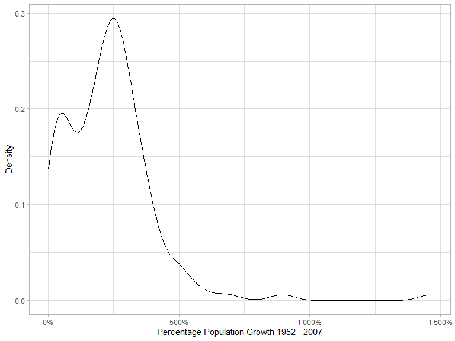

## group_by and summarize

- Do calculations within-group to get a data set that has one observation for each unique group-variable combination

```r
gapminder %>%
  mutate(after_1980 = year >= 1980) %>%
  group_by(continent, after_1980) %>%
  summarize(`Life Expectancy` = mean(lifeExp),
            `GDP Per Capita` = mean(gdpPercap)) %>%
  kable(title = 'Life Expectancy and GDP Per Capita by Continent')
```

## group_by and summarize

- Do calculations within-group to get a data set that has one observation for each unique group-variable combination

Life Expectancy and GDP Per Capita by Continent

| continent | after_1980 | Life Expectancy | GDP Per Capita |
| --- | --- | --- | --- |
| Africa | FALSE | 44.34787 | 1868.634 |
| Africa | TRUE | 53.38279 | 2518.875 |
| Americas | FALSE | 59.13938 | 5518.040 |
| Americas | TRUE | 70.17809 | 8754.180 |
| Asia | FALSE | 53.13160 | 6443.757 |
| Asia | TRUE | 66.99820 | 9360.544 |
| Europe | FALSE | 68.68353 | 9649.489 |
| Europe | TRUE | 75.12384 | 19289.462 |
| Oceania | FALSE | 71.11833 | 13798.229 |
| Oceania | TRUE | 77.53408 | 23444.990 |

## rename

- Onto some less key aspects!
- `rename` lets you rename variables
- This can be for your own purposes, or to make something look nice for a graph or table without figuring out the **ggplot2** variable-renaming system

```r
mtcars <- mtcars %>%
  rename(MPG = mpg,
         Horsepower = hp)
```

## case_when

- `case_when` is often used with `mutate` when you want to create a variable where its values are based on conditions
- It “sieves”, so each level is only seen if the previous condition fails. The last one can be `TRUE` as a catchall

```r
mtcars <- mtcars %>%
  mutate(MPG_quality = case_when(
    MPG > 30 ~ 'Bad',
    MPG > 19 ~ 'Okay',
    MPG > 15 ~ 'Good',
    TRUE ~ 'Fantastic!'
  ))
```

## Practice

- We’ve learned a lot of R tricks in **ggplot2** and **dplyr**
- Let’s put those skills in motion!
- Please check back on previous lecture slides for tips and remembering code
- “Googling stuff” and looking stuff up is an essential part of coding

## Imitation and Flattery

- Using `library(car); data(Vocab)` (then see `help(Vocab)` for variable definitions)
- You’ll need a `mutate` (with `floor()`) to get the decade vairable
- Then `group_by` and `summarize` (and don’t forget `ggannotate`!)
- Palette is `'ggsci::alternating_igv'`

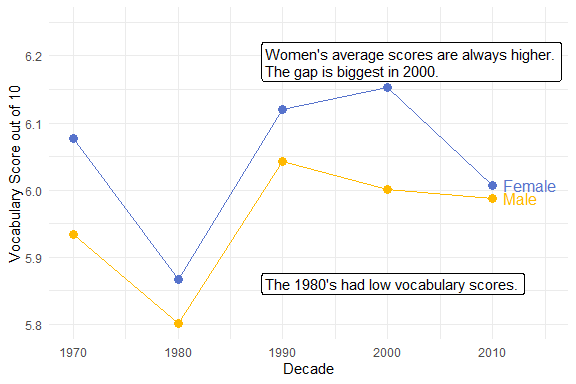

## Imitation and Flattery

```r
library(paletteer); library(carData); library(directlabels)
data(Vocab)
Vocab %>%
  mutate(decade = floor(year/10)*10) %>%
  group_by(decade,sex) %>%
  summarize(vocabulary=mean(vocabulary)) %>%
  ggplot(aes(x = decade, y = vocabulary, color = sex)) +
  geom_line() + geom_point(size=3) +
  theme_minimal() +
  scale_x_continuous(limits=c(1970,2015)) +
  scale_y_continuous(limits=c(5.8,6.25))+
  scale_color_paletteer_d('ggsci::alternating_igv') +
  labs(x = "Decade", y = "Vocabulary Score out of 10") +
  guides(color = FALSE) +
  geom_dl(aes(x = decade + 1,label=sex),method='last.bumpup')+
  [ggannotate additions]
```

## Imitation and Flattery

- Data from `https://vincentarelbundock.github.io/Rdatasets/csv/DAAG/carprice.csv`
- Another `group_by` and `summarize`. Then `gghighlight`!
- Theme is `theme_tufte` from **ggthemes**… but where did those y-axis ticks go?

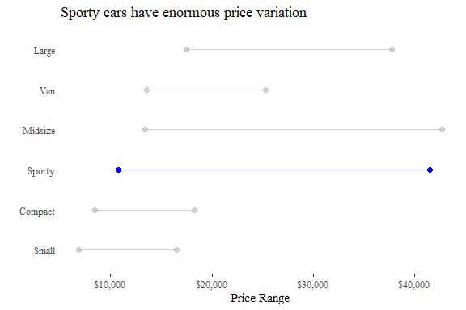

## Imitation and Flattery

```r
library(gghighlight); library(ggalt); library(ggthemes)
df <- read_csv('https://vincentarelbundock.github.io/Rdatasets/csv/DAAG/carprice.csv')
df %>%
  group_by(Type) %>%
  summarize(Min.Price = min(Min.Price),
            Max.Price = max(Max.Price)) %>%
  mutate(Min.Price = Min.Price*1000,
         Max.Price = Max.Price*1000) %>%
  ggplot(aes(x = Min.Price, xend = Max.Price, y = Type)) +
  geom_dumbbell(size_x = 2, size_xend = 2, color = 'blue') +
  labs(x = 'Price Range',y = '',title='Sporty cars have enormous price variation') +
  scale_y_discrete(limits = c('Small','Compact','Sporty','Midsize','Van','Large'))+
  scale_x_continuous(labels = scales::dollar)+
  theme_tufte() +
  theme(axis.ticks.y = element_blank())+
  gghighlight(Type == 'Sporty')
```

## Imitation and Flattery

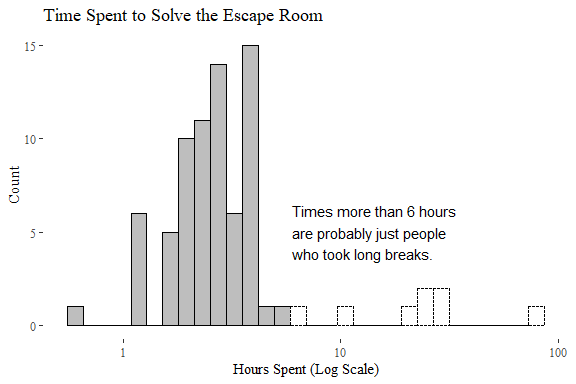

## Imitation and Flattery

```r
library(ggforce)
df <- read_csv('https://nickchk.com/cgi-bin/winning_times.csv')
df %>%
  mutate(hours = secs/(60*60)) %>%
  ggplot(aes(x = hours, linetype = hours > 6, fill = hours > 6)) +
  geom_histogram(color='black') +
  scale_fill_manual(values = c(`TRUE` = 'white',`FALSE` = 'gray'))+
  scale_x_log10() +
  labs(x = 'Hours Spent (Log Scale)', y = 'Count',
       title = 'Time Spent to Solve the Escape Room') +
  guides(linetype=FALSE,fill=FALSE) +
  theme_tufte() +
  annotate(geom='text',hjust=0,label='Times more than 6 hours\nare probably just people\nwho took long breaks.',x=6,y=5)
```

## Imitation and Flattery

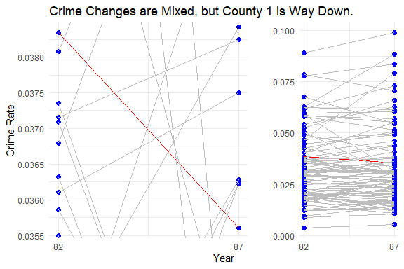

## Imitation and Flattery

```r
library(wooldridge); library(ggforce); data(crime4)
crime4 %>%
  filter(year %in% c(82,87)) %>%
  ggplot(aes(x = year, y = crmrte, group = county, color = county == 1)) +
  geom_point(color = 'blue',size = 2) +
  geom_line() +
  scale_color_manual(values = c(`TRUE`='red',`FALSE`='gray'))+
  scale_x_continuous(breaks = c(82,87))+
  labs(x = 'Year',y = 'Crime Rate',title = 'Crime Changes are Mixed, but County 1 is Way Down.') +
  theme_minimal() +
  guides(color = FALSE)+
  facet_zoom(y=county == 1)
```